# MA213 Basic Statistics and Probability - Lab6

# **Lab 6: Regression**

In this lab session, we will explore concepts of regression.

#### Learning Objectives

- **Compute and Interpret Correlation and R²**: Compute and interpret correlation coefficients and R² values, while recognizing that correlation does not imply causation.
- **Describe and Assess Relationships Between Two Variables**: Describe the association between two numerical variables in a scatter plot in terms of direction, shape (linear or nonlinear), and strength, and assess whether linear regression is an appropriate model.
- **Fit and Interpret Linear Models Using Least Squares**: Fit the intercept and slope of a linear model to data using the least squares method, interpret the fitted values, and use the model to predict responses to new inputs.
- **Perform Inference for Regression Coefficients**: Use fit summary and parameter estimates (e.g., $\hat{\beta_1}$ and $\hat{\sigma^2}$ ) to perform hypothesis tests or construct confidence intervals for the slope, and interpret the results.

## Pre-lab activities

```r
num_ppl_each_group = 4
student_list <- read.csv("StudentList.csv")
N <- nrow(student_list)

# Sort by last name
student_list <- student_list %>% arrange(Last)
student_list$number <- 1:N

# Shuffle the student numbers randomly
shuffled <- sample(student_list$number)

# Create group
group_ids <- rep(1:ceiling(N / num_ppl_each_group), num_ppl_each_group)[1:N]

# Assign data frame
group_df <- data.frame(number = shuffled, group = group_ids)
grouped_students <- left_join(group_df, student_list, by = "number")

grouped_students <- grouped_students %>% arrange(group)

# Output
grouped_students %>% select(!number)
```

```
##    group First Last
## 1      1     O   OO
## 2      1     H   HH
## 3      1     E   EE
## 4      1     N   NN
## 5      2     I   II
## 6      2     B   BB
## 7      2     X   XX
## 8      2     M   MM
## 9      3     A   AA
## 10     3     V   VV
## 11     3     G   GG
## 12     3     U   UU
## 13     4    A2  AA2
## 14     4     L   LL
## 15     4     S   SS
## 16     4     T   TT
## 17     5     K   KK
## 18     5    C2  CC2
## 19     5     J   JJ
## 20     5     P   PP
## 21     6     R   RR
## 22     6    B2  BB2
## 23     6     Y   YY
## 24     7     W   WW
## 25     7     C   CC
## 26     7     F   FF
## 27     8     Q   QQ
## 28     8     Z   ZZ
## 29     8     D   DD
```

### Lab activities

Many college courses conclude by giving students the opportunity to evaluate the course and the instructor anonymously. However, the use of these student evaluations as an indicator of course quality and teaching eﬀectiveness is often criticized because these measures may reflect the influence of non-teaching related characteristics, such as the physical appearance of the instructor. Researchers at University of Texas, Austin collected data on teaching evaluation score (higher score means better) and standardized beauty score (a score of 0 means average, negative score means below average, and a positive score means above average) for a sample of 463 professors. (The data was originally considered by Hamermesh and Parker (2005).)

1. Data loading & data cleaning

```r
library(dplyr)
library(ggplot2)

df <- read.csv("beauty.csv")

glimpse(df)
```

```
## Rows: 463
## Columns: 12
## $ minority    <chr> "yes", "no", "no", "no", "no", "no", "no", "no", "no", "no…
## $ age         <int> 36, 59, 51, 40, 31, 62, 33, 51, 33, 47, 35, 37, 42, 49, 37…
## $ gender      <chr> "female", "male", "male", "female", "female", "male", "fem…
## $ credits     <chr> "more", "more", "more", "more", "more", "more", "more", "m…
## $ beauty      <dbl> 0.2899157, -0.7377322, -0.5719836, -0.6779634, 1.5097940, …
## $ eval        <dbl> 4.3, 4.5, 3.7, 4.3, 4.4, 4.2, 4.0, 3.4, 4.5, 3.9, 3.1, 4.0…
## $ division    <chr> "upper", "upper", "upper", "upper", "upper", "upper", "upp…
## $ native      <chr> "yes", "yes", "yes", "yes", "yes", "yes", "yes", "yes", "y…
## $ tenure      <chr> "yes", "yes", "yes", "yes", "yes", "yes", "yes", "yes", "y…
## $ students    <int> 24, 17, 55, 40, 42, 182, 33, 25, 48, 16, 18, 30, 28, 30, 2…
## $ allstudents <int> 43, 20, 55, 46, 48, 282, 41, 41, 60, 19, 25, 34, 40, 36, 2…
## $ prof        <int> 1, 2, 3, 4, 5, 6, 7, 8, 9, 10, 11, 12, 13, 14, 15, 16, 17,…
```

```r
head(df)
```

```
##   minority age gender credits     beauty eval division native tenure students
## 1      yes  36 female    more  0.2899157  4.3    upper    yes    yes       24
## 2       no  59   male    more -0.7377322  4.5    upper    yes    yes       17
## 3       no  51   male    more -0.5719836  3.7    upper    yes    yes       55
## 4       no  40 female    more -0.6779634  4.3    upper    yes    yes       40
## 5       no  31 female    more  1.5097940  4.4    upper    yes    yes       42
## 6       no  62   male    more  0.5885687  4.2    upper    yes    yes      182
##   allstudents prof
## 1          43    1
## 2          20    2
## 3          55    3
## 4          46    4
## 5          48    5
## 6         282    6
```

```r
#
# df2 <- df %>% filter(event == "10 Mile") %>% select_all()
#
# df2 %>%
#   count(city, sort = TRUE) %>%  # count and sort by frequency (descending)
#   slice_head(n = 100)
#
# df3 <- df2 %>% filter(city=="Warrenton, VA") %>% select_all()
# cor(df3$age, df3$clock_sec)
```

2. linear relationships

scatter plot

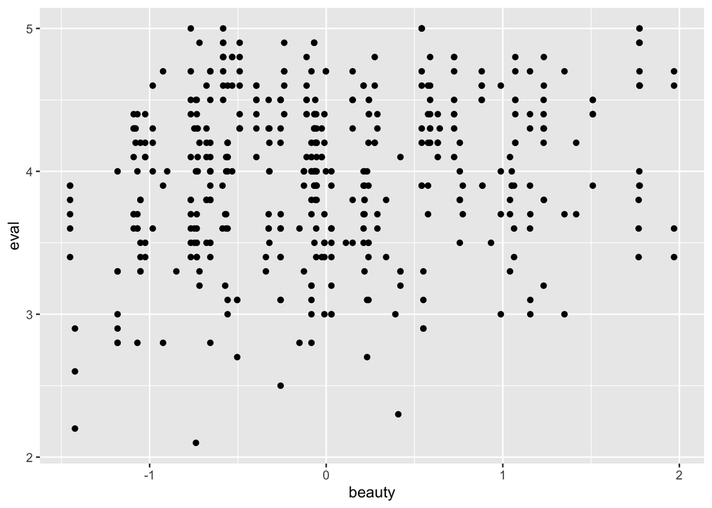

```r
X = df$beauty
Y = df$eval


ggplot(data=df, mapping = aes(x=beauty, y=eval)) + geom_point()
```

```r
#
#
#
```

Let’s also check correlation between `beauty` and `eval`.

Correlation
$$R = \frac{1}{n-1} \sum_{i=1}^{n} \frac{x_i - \bar{x}}{s_{x}} \frac{y_i -
\bar{y}}{s_{y}}$$
where $s_x$ is the standard deviation of explanatory variable $x$ and $s_y$ is the standard deviation of response variable.

#### Exercise

let’s obtain the correlation $R$ using R.

```r
sx = sd(X)
sy = sd(Y)
xbar = mean(X)
ybar = mean(Y)


n = length(X)

summation = 0

for (i in 1:n){
  summation = summation + ( (X[i] - xbar)/sx ) * ((Y[i] - ybar)/sy )

}

R = summation/(n-1)
R
```

```
## [1] 0.1890391
```

```r
# cor(df3$age, df3$clock_sec)
```

3. linear model and summary

do i need to use formula…?

The model is
$$y = \beta_0 + \beta_1 x + \epsilon$$
The estimates are
$$b_1 = \hat{\beta_1} = (\frac{s_y}{s_x}) R,$$

$$b_0 = \hat{\beta_0} = \bar{y} - b_1 \bar{x}$$

#### Exercise

Let’s obtain the least squares line

```r
#
b1 = (sy/sx)*R
b0 = ybar - b1 * xbar
y_hat = b0+ b1*X

Resid = Y-y_hat
```

Let’s interpret the result

```r
#
# Question... Can we use lm() function?
#
model = lm(Y~X)
summary(model)
```

```
##
## Call:
## lm(formula = Y ~ X)
##
## Residuals:
##      Min       1Q   Median       3Q      Max
## -1.80015 -0.36304  0.07254  0.40207  1.10373
##
## Coefficients:
##             Estimate Std. Error t value Pr(>|t|)
## (Intercept)  3.99827    0.02535 157.727  < 2e-16 ***
## X            0.13300    0.03218   4.133 4.25e-05 ***
## ---
## Signif. codes:  0 '***' 0.001 '**' 0.01 '*' 0.05 '.' 0.1 ' ' 1
##
## Residual standard error: 0.5455 on 461 degrees of freedom
## Multiple R-squared:  0.03574,    Adjusted R-squared:  0.03364
## F-statistic: 17.08 on 1 and 461 DF,  p-value: 4.247e-05
```

4. Assumption check

```r
#
#
#
```

5. Model diagnostic

```r
#
#
#
```

### Post-lab activities

Please name your submission as `lab6.R`

Hamermesh, Daniel S, and Amy Parker. 2005. “Beauty in the Classroom: Instructors’ Pulchritude and Putative Pedagogical Productivity.” *Economics of Education Review* 24 (4): 369–76.